# Presidential Inaugural Speech Analysis, by Michael Utomo

Content: (1) Analysis of the number of words in a sentence presidential speeches. (2) Analysis of American politics through presidential inaugural speeches. The analysis for the “storyline” are based on each parties. The Republican Party generally advocates for small-government, with the exception of security and borders. The Democratic Party represents the big-government that generally concerns about welfare. In this qualitative analyses, we would like to show whether these generalization is true or not. This is done for Republicans and Democrats only, ignoring other major parties that existed in the US before them. (3) Speech analysis by the Founding Fathers.

0.) Package Preparation Download all the packages needed for data analyses purposes.

```r
packages.used=c("rvest", "tibble", "qdap",
                "sentimentr", "gplots", "dplyr",
                "tm", "syuzhet", "factoextra",
                "beeswarm", "scales", "RColorBrewer",
                "RANN", "tm", "topicmodels")
# check packages that need to be installed.
packages.needed=setdiff(packages.used,
                        intersect(installed.packages()[,1],
                                  packages.used))
# install additional packages
if(length(packages.needed)>0){
  install.packages(packages.needed, dependencies = TRUE)
}
# load packages
library("rvest")
library("tibble")
# You may need to run
# sudo ln -f -s $(/usr/libexec/java_home)/jre/lib/server/libjvm.dylib /usr/local/lib
# in order to load qdap
library("qdap")
library("sentimentr")
library("gplots")
library("dplyr")
library("tm")
library("syuzhet")
library("factoextra")
library("beeswarm")
library("scales")
library("RColorBrewer")
library("RANN")
library("tm")
library("topicmodels")
library("xml2")
source("../lib/plotstacked.R")
source("../lib/speechFuncs.R")
```

1.) Find the inaugural speech date and make sure that every speeches are downloaded

```r
### Inaugural speeches
main.page <- read_html(x = "http://www.presidency.ucsb.edu/inaugurals.php")
# Get link URLs
# f.speechlinks is a function for extracting links from the list of speeches.
inaug=f.speechlinks(main.page)
#head(inaug)
as.Date(inaug[,1], format="%B %e, %Y")
```

```
 [1] "1789-04-30" "1793-03-04" "1797-03-04" "1801-03-04" "1805-03-04" "1809-03-04" "1813-03-04" "1817-03-04" "1821-03-04"
[10] "1825-03-04" "1829-03-04" "1833-03-04" "1837-03-04" "1841-03-04" "1845-03-04" "1849-03-05" "1853-03-04" "1857-03-04"
[19] "1861-03-04" "1865-03-04" "1869-03-04" "1873-03-04" "1877-03-05" "1881-03-04" "1885-03-04" "1889-03-04" "1893-03-04"
[28] "1897-03-04" "1901-03-04" "1905-03-04" "1909-03-04" "1913-03-04" "1917-03-04" "1921-03-04" "1925-03-04" "1929-03-04"
[37] "1933-03-04" "1937-01-20" "1941-01-20" "1945-01-20" "1949-01-20" "1953-01-20" "1957-01-21" "1961-01-20" "1965-01-20"
[46] "1969-01-20" "1973-01-20" "1977-01-20" "1981-01-20" "1985-01-21" "1989-01-20" "1993-01-20" "1997-01-20" "2001-01-20"
[55] "2005-01-20" "2009-01-20" "2013-01-21" "2017-01-20" NA
```

```r
inaug=inaug[-nrow(inaug),] # remove the last line, irrelevant due to error.
```

2.) Using speech metadata

```r
inaug.list=read.csv("../data/inauglist.csv", stringsAsFactors = FALSE)
```

3.) Scrap the text

```r
speech.list=inaug.list
speech.list$type=c(rep("inaug", nrow(inaug.list)))
speech.url=inaug
speech.list=cbind(speech.list, speech.url)
```

```r
# Loop over each row in speech.list
speech.list$fulltext=NA
for(i in seq(nrow(speech.list))) {
  text <- read_html(speech.list$urls[i]) %>% # load the page
    html_nodes(".displaytext") %>% # isloate the text
    html_text() # get the text
  speech.list$fulltext[i]=text
  # Create the file name
  filename <- paste0("../data/fulltext/",
                     speech.list$type[i],
                     speech.list$File[i], "-",
                     speech.list$Term[i], ".txt")
  sink(file = filename) %>% # open file to write
  cat(text)  # write the file
  sink() # close the file
}
```

4.) Generate list of sentences

```r
sentence.list=NULL
for(i in 1:nrow(speech.list)){
  sentences=sent_detect(speech.list$fulltext[i],
                        endmarks = c("?", ".", "!", "|",";"))
  if(length(sentences)>0){
    emotions=get_nrc_sentiment(sentences)
    word.count=word_count(sentences)
    # colnames(emotions)=paste0("emo.", colnames(emotions))
    # in case the word counts are zeros?
    emotions=diag(1/(word.count+0.01))%*%as.matrix(emotions)
    sentence.list=rbind(sentence.list,
                        cbind(speech.list[i,-ncol(speech.list)],
                              sentences=as.character(sentences),
                              word.count,
                              emotions,
                              sent.id=1:length(sentences)
                              )
    )
  }
}
```

Some non-sentences exist in raw data due to erroneous extra end-of-sentence marks.

```r
sentence.list=
  sentence.list%>%
  filter(!is.na(word.count))
```

5.) Data Analysis Average length of speech Data Visualization each president

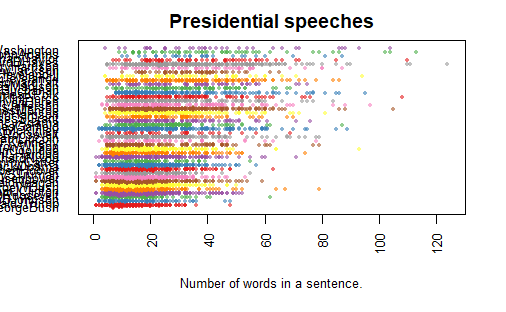

```r
sentence.list$FileOrdered=reorder(sentence.list$File,sentence.list$word.count, mean,order=T)
beeswarm(word.count~FileOrdered,
         data=sentence.list,
         horizontal = TRUE,
         pch=16, col=alpha(brewer.pal(9, "Set1"), 0.6),
         cex=0.55, cex.axis=0.8, cex.lab=0.8,
         spacing=5/nlevels(sentence.list$FileOrdered),
         las=2, xlab="Number of words in a sentence.", ylab="",
         main="Presidential speeches")
```

6.) Topic Modelling

Divide topic based on political parties and Founding Fathers

```r
rep.sentence.list = subset(sentence.list, sentence.list$Party == 'Republican')
dem.sentence.list = subset(sentence.list, sentence.list$Party == 'Democratic')

## Founding Fathers
founding.fathers <- c('GeorgeWashington', 'JohnAdams', 'ThomasJefferson', 'JamesMadison')
fathers.i <- sentence.list$FileOrdered %in% founding.fathers
fathers.list <- sentence.list[fathers.i,]
fathers.list$Party <- 'FoundingFathers'

political.list <- list(rep.sentence.list, dem.sentence.list, fathers.list)
```

LDA

```r
for (i in 1:length(political.list)){
        this.list <- political.list[[i]]
        this.party = unique(this.list$Party)
        this.party <- this.party[!is.na(this.party)]
        # Party LDA
        corpus.list=this.list[2:(nrow(this.list)-1), ]
        sentence.pre=this.list$sentences[1:(nrow(this.list)-2)]
        sentence.post=this.list$sentences[3:(nrow(this.list)-1)]
        corpus.list$snipets=paste(sentence.pre, corpus.list$sentences, sentence.post, sep=" ")
        rm.rows=(1:nrow(corpus.list))[corpus.list$sent.id==1]
        rm.rows=c(rm.rows, rm.rows-1)
        #corpus.list=corpus.list[-rm.rows, ]

        # Text Mining
        docs <- Corpus(VectorSource(corpus.list$snipets))



        #remove potentially problematic symbols
        docs <-tm_map(docs,content_transformer(tolower))


        #remove punctuation
        docs <- tm_map(docs, removePunctuation)


        #Strip digits
        docs <- tm_map(docs, removeNumbers)


        #remove stopwords
        docs <- tm_map(docs, removeWords, stopwords("english"))


        #remove whitespace
        docs <- tm_map(docs, stripWhitespace)


        #Stem document
        docs <- tm_map(docs,stemDocument)


        ### Topic modeling
        dtm <- DocumentTermMatrix(docs)
        #convert rownames to filenames#convert rownames to filenames
        rownames(dtm) <- paste(corpus.list$type, corpus.list$File,
                               corpus.list$Term, corpus.list$sent.id, sep="_")

        rowTotals <- apply(dtm , 1, sum) #Find the sum of words in each Document

        dtm  <- dtm[rowTotals> 0, ]
        corpus.list=corpus.list[rowTotals>0, ]


        # Run LDA
        #Set parameters for Gibbs sampling
        burnin <- 20
        iter <- 2000
        thin <- 50
        seed <- 013018
        nstart <- 1
        best <- TRUE

        #Number of topics
        k <- 9

        #Run LDA using Gibbs sampling
        ldaOut <-LDA(dtm, k, method="Gibbs", control=list(nstart=nstart,
                                                          seed = seed, best=best,
                                                          burnin = burnin, iter = iter,
                                                          thin=thin))
        #write out results
        #docs to topics
        ldaOut.topics <- as.matrix(topics(ldaOut))
        table(c(1:k, ldaOut.topics))
        write.csv(ldaOut.topics,file=paste0("LDAGibbs",k,this.party,"DocsToTopics.csv"))

        #top 6 terms in each topic
        ldaOut.terms <- as.matrix(terms(ldaOut,20))
        write.csv(ldaOut.terms,file=paste0("LDAGibbs",k,this.party,"TopicsToTerms.csv"))
        print(paste("Words Distributions for ", this.party))
        print(ldaOut.terms)
        #probabilities associated with each topic assignment
        topicProbabilities <- as.data.frame(ldaOut@gamma)
        write.csv(topicProbabilities,file=paste0("LDAGibbs",k,this.party,"TopicProbabilities.csv"))
}
```

```
[1] "Words Distributions for  Republican"
      Topic 1    Topic 2   Topic 3    Topic 4    Topic 5     Topic 6    Topic 7   Topic 8     Topic 9
 [1,] "freedom"  "peopl"   "countri"  "nation"   "govern"    "congress" "one"     "law"       "will"
 [2,] "free"     "will"    "great"    "world"    "must"      "may"      "time"    "state"     "can"
 [3,] "american" "shall"   "unit"     "peac"     "secur"     "busi"     "year"    "right"     "america"
 [4,] "hope"     "upon"    "parti"    "war"      "everi"     "industri" "god"     "constitut" "new"
 [5,] "peopl"    "govern"  "question" "must"     "public"    "upon"     "presid"  "citizen"   "make"
 [6,] "know"     "power"   "polit"    "seek"     "without"   "product"  "histori" "now"       "let"
 [7,] "men"      "duti"    "made"     "forc"     "now"       "effect"   "day"     "union"     "work"
 [8,] "life"     "offic"   "respect"  "never"    "can"       "labor"    "today"   "enforc"    "mean"
 [9,] "human"    "purpos"  "upon"     "honor"    "system"    "encourag" "call"    "exist"     "american"
[10,] "faith"    "may"     "elect"    "justic"   "much"      "legisl"   "man"     "protect"   "better"
[11,] "long"     "execut"  "effort"   "way"      "necessari" "proper"   "come"    "whole"     "everi"
[12,] "liberti"  "civil"   "best"     "help"     "prosper"   "trade"    "earth"   "race"      "old"
[13,] "thing"    "support" "differ"   "strength" "present"   "chang"    "first"   "danger"    "live"
```

[output cut: 51 more lines]

7.) Analysis of the most words used using WordCloud WordCloud for Democratic Party:

```r
#Read the file
library(tidytext)
library(wordcloud)
preprocess_data<- function(sentence.list){
  corpus.list=sentence.list[2:(nrow(sentence.list)-1), ]
  sentence.pre=sentence.list$sentences[1:(nrow(sentence.list)-2)]
  sentence.post=sentence.list$sentences[3:(nrow(sentence.list)-1)]
  corpus.list$snipets=paste(sentence.pre, corpus.list$sentences, sentence.post, sep=" ")
  rm.rows=(1:nrow(corpus.list))[corpus.list$sent.id==1]
  rm.rows=c(rm.rows, rm.rows-1)
  corpus.list=corpus.list[-rm.rows, ]
  docs <- Corpus(VectorSource(corpus.list$snipets))
  #remove potentially problematic symbols
  docs <-tm_map(docs,content_transformer(tolower))

  #remove punctuation
  docs <- tm_map(docs, removePunctuation)

  #Strip digits
  docs <- tm_map(docs, removeNumbers)

  #remove stopwords
  docs <- tm_map(docs, removeWords, stopwords("english"))

  #remove whitespace
  docs <- tm_map(docs, stripWhitespace)

  #Stem document
  docs <- tm_map(docs,stemDocument)

  return(docs)
}
#Creating the WordCloud
docs <- preprocess_data(dem.sentence.list)
tdm.all<-TermDocumentMatrix(docs)
tdm.tidy=tidy(tdm.all)
tdm.overall=summarise(group_by(tdm.tidy, term), sum(count))
tdm.overall[with(tdm.overall, order(-`sum(count)`)), ]
```

| term | sum(count) |
| --- | --- |
| will | 875 |
| nation | 728 |
| peopl | 648 |
| govern | 628 |
| can | 495 |
| power | 415 |
| must | 411 |
| state | 404 |
| world | 375 |
| everi | 353 |

[output cut: 990 more lines]

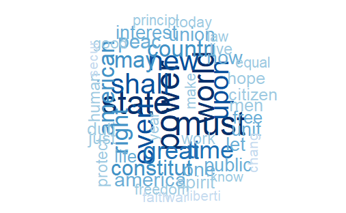

```r
tdm.overall <- tdm.overall[with(tdm.overall, order(-`sum(count)`)), ]
tdm.overall <- tail(tdm.overall,-5)
wordcloud(tdm.overall$term, tdm.overall$`sum(count)`,
          scale=c(3,0.5),
          max.words=50,
          min.freq=1,
          random.order=FALSE,
          rot.per=0.3,
          use.r.layout=T,
          random.color=FALSE,
          colors=brewer.pal(9,"Blues")
         )
```

WordCloud for Republican Party:

```r
#Creating the WordCloud
docs <- preprocess_data(rep.sentence.list)
tdm.all<-TermDocumentMatrix(docs)
tdm.tidy=tidy(tdm.all)
tdm.overall=summarise(group_by(tdm.tidy, term), sum(count))
tdm.overall[with(tdm.overall, order(-`sum(count)`)), ]
```

| term | sum(count) |
| --- | --- |
| will | 1479 |
| nation | 897 |
| peopl | 834 |
| govern | 820 |
| can | 675 |
| must | 597 |
| world | 570 |
| upon | 567 |
| law | 551 |
| great | 508 |

[output cut: 990 more lines]

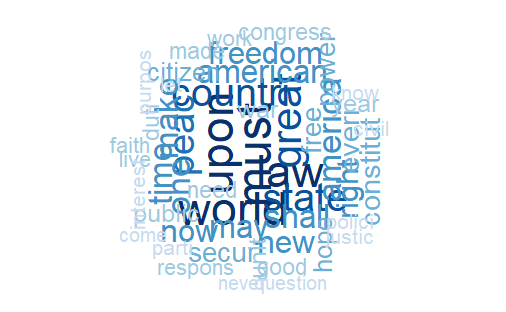

```r
tdm.overall <- tdm.overall[with(tdm.overall, order(-`sum(count)`)), ]
tdm.overall <- tail(tdm.overall,-5)
wordcloud(tdm.overall$term, tdm.overall$`sum(count)`,
          scale=c(3,0.5),
          max.words=50,
          min.freq=1,
          random.order=FALSE,
          rot.per=0.3,
          use.r.layout=T,
          random.color=FALSE,
          colors=brewer.pal(9,"Blues")
         )
```

2.) The analysis of the Republican ideology based on topic modelling:

-Freedom Republicans generally prefers freedom compared to anything else. This what differentiates Republicans and Democrats. The way they defines freedom is that the government should not interfere with peoples’ life. From the first column, it is clear the central tenents of Republican ideology, faith and freedom.

-Faith This is central to Republican Party’s ideology that it promotes social conservatism. Social conservatism generally promotes preservation of traditional religious beliefs. In this case, the words are similar to what religious people talk about, in particular Christianity.

-Free Market The Republican Party encourages free trade as its economic policies. From Topic 6, it is clear that the words that are related to that: trade, business, increase, import.

3.) The analysis of the Democratic ideology based on topic modelling:

-Progessivism The Democratic Party represents the progress of America. This goes back to their main ideology of social liberalism. The party is currently supporting LGBT rights, affirmative action, path of citizenship for illegal/undocumented immigrants. From Tppic 1 and 5, it is clear that there are words like progressive, new, change.

-Equality This is related to progressivism that I have described above. From Topic 4, it is clear that this is the case because equality is in the same bracket as the government. The Democratic Party believes that the government’s job is to provide social equity for all citizens.

4.) The analysis of Founding fathers’ ideology based on topic modelling:

-Function of government State, consitute, Happy, love in Topic 2 provides what the Founding Fathers’ belief about function of government. In the Declaration of Independence, the founding fathers’ wrote about the function of government is to provide life, liberty, and the pursuit of happiness to its citizens.

-Independence At that time, the United States is still a new country and they just had war with Britain. So, in topic 3, they are talking about building a new country after war. Words that are associated with independence are nation, war, success.

-Rationalism/Deism This was what the founding fathers’ belief with general population in that time. Founding Fathers that became presidents mostly believed that rationalism trumps everything. This evidence is corroborated by the fact that they are all deists. Deists believes that anything should be explained in rational and empirical sense. This is clear from Topic 9.

5.) WordCloud: In the Wordcloud, it is clear that the top five words that are being used for inaugural speeches are the same for both parties. But, if you dig it deeper, the same analysis will come up like in the 2 and 3.

6.) Limitations of the Modelling: - The biggest limitation of the model is that it assumes that the party’s ideology is constant over time. For example, in the early time of the Democratic Party, the party supported slavery and now, the Democratic Party represents the party that supports civil rights.

References: 1.) Ellis, J. J. (2017, February 03). Founding Fathers. Retrieved January 31, 2018, from https://www.britannica.com/topic/Founding-Fathers#ref261052 2.) Micklethwait, J., & Wooldridge, A. (2015). The fourth revolution: the global race to reinvent the state. New York, NY: Penguin Books. 3.) The Editors of Encyclopædia Britannica. (2017, December 14). Democratic Party. Retrieved January 31, 2018, from https://www.britannica.com/topic/Democratic-Party 4.) The Editors of Encyclopædia Britannica. (2018, January 05). Republican Party. Retrieved January 31, 2018, from https://www.britannica.com/topic/Republican-Party

Code Reference: 1.) Wk2-Tutorial-TextMining. (n.d.). Retrieved January 30, 2018, from https://github.com/TZstatsADS/ADS_Teaching/blob/master/Tutorials/wk2-TextMining/doc/wk2-Tutorial-TextMining.Rmd

2.) A: Interactive R Notebook. (n.d.). Retrieved January 31, 2018, from https://github.com/TZstatsADS/ADS_Teaching/blob/master/Tutorials/wk2-TextMining/doc/InteractiveWordCloud.Rmd